# Time_Series_Regression_II

# Libraries

```r
library(fpp3)
library(latex2exp)
library(patchwork)
```

# References

1. Forecasting Principles and Practice - 3rd Edition - [Link](https://otexts.com/fpp3/index.html)
2. Cornell Statistical Unit - Interpretation of the coefficients and back-transform of a log-log, log-linear, linear-log regression [Link](https://cscu.cornell.edu/wp-content/uploads/83_logv.pdf)
3. Fourier coefficients and long seasonal periods. Rob Hyndman [Link](https://robjhyndman.com/hyndsight/longseasonality/),
4. Facebooks Prophet Model - fpp3 chapter - [Link](https://otexts.com/fpp3/prophet.html)
5. Documentation for `common_xregs` in the fable library. - [Link](https://fable.tidyverts.org/reference/common_xregs.html)
6. Shether - Linear models

# Some useful predictos

These are some predictors that are frequently used in time series regression:

## Trend

A linear trend can be modelled by uing $t$ as a predictor:

$$\begin{align*}
y_{t}= \beta_0+\beta_1t+\varepsilon_t
\end{align*}$$

This can be easily within the `TSLM()` model using the `trend()` special.

### Piecewise trend. Example

If there are changes in the slope, it is sometimes useful to model them useing a piecewise linear trend. We will explore this with an example. Let us look at the downwards trend of the Boston marathon times.

We extract men data and convert winning times to a numerical value. we first fit a linear trend model:

```r
boston_men <- boston_marathon %>%
  filter(Year >= 1924) %>%
  filter(Event == "Men's open division") %>%
  mutate(Minutes = as.numeric(Time)/60) %>%
  select(Year, Minutes)

boston_men
```

```
# A tsibble: 96 x 2 [1Y]
    Year Minutes
   <int>   <dbl>
 1  1924    150.
 2  1925    153
 3  1926    146.
 4  1927    160.
 5  1928    157.
 6  1929    153.
 7  1930    155.
 8  1931    167.
 9  1932    154.
10  1933    151.
# ... with 86 more rows
```

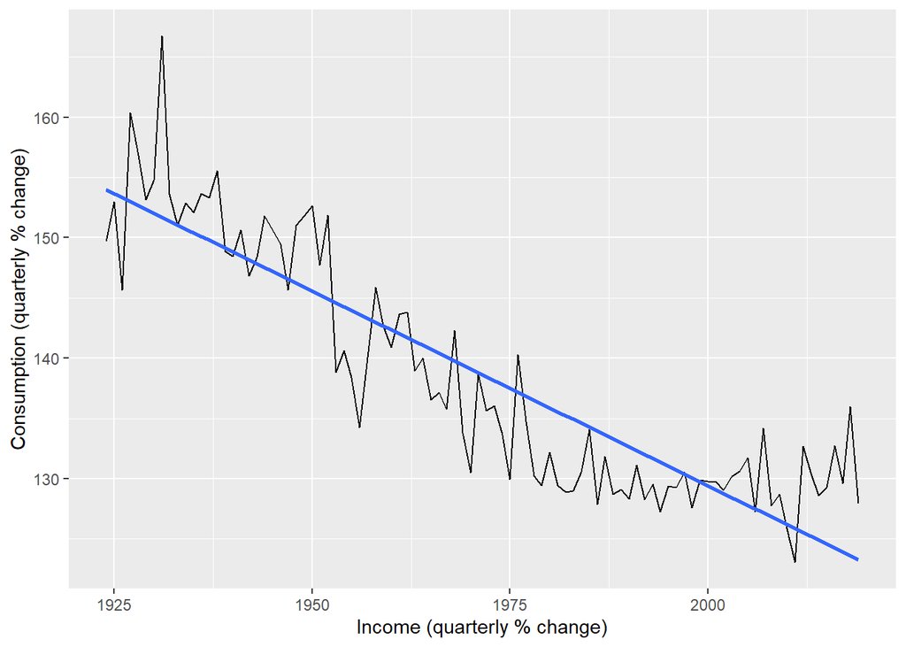

```r
boston_men %>%
  ggplot(aes(x = Year, y = Minutes)) +
  labs(y = "Consumption (quarterly % change)",
       x = "Income (quarterly % change)") +
  geom_line() +
  geom_smooth(method = "lm", formula="y ~ x", se = FALSE)
```

```
Plot variable not specified, automatically selected `.vars = .innov`
```

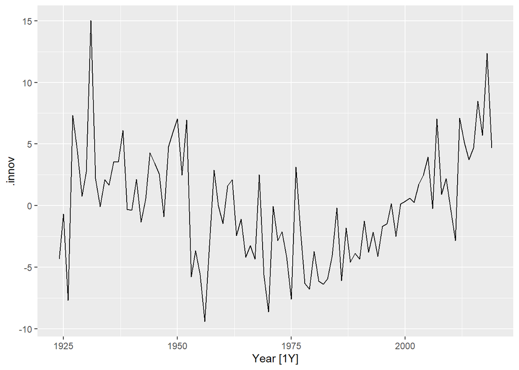

```r
TSLM_boston <-
  boston_men %>%
  model(TSLM(Minutes ~ trend()))

resid <- TSLM_boston %>% augment() %>% select(Year, .innov)

resid %>% autoplot()
```

The residuals clearly show a growing pattern from 1975 onwards. This indicates that that the linear assumption does not hold, particularly from 1980 onwards. This is clearly visible in the timpeplot of the data, since the winning times seem to stagnate from 1980 onwards. Most of the reduction in winning times takes place between 1950 and 1980. We will fit a piecewise linear regression with two knows, one at 1950 and one at 1980.

- NOTE: subjective identification of the notes can lead to overfitting and should be performed with caution. As an example, the Prophet model of facebook (ref. 4) uses a Bayesian approach to identify the changes in trend.

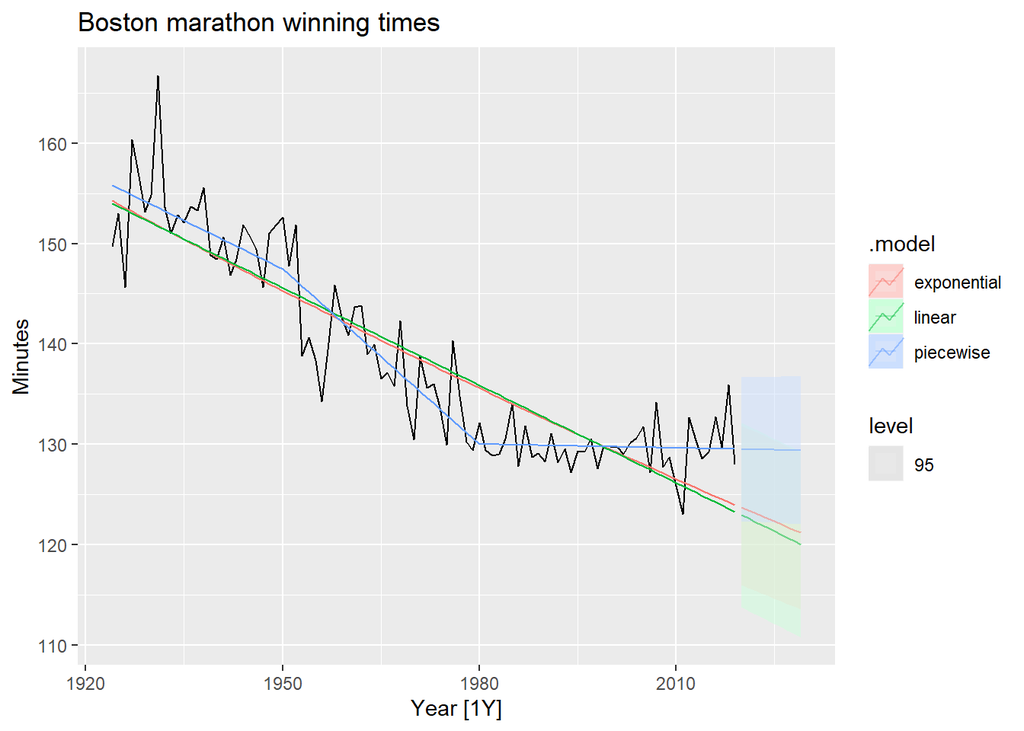

```r
fit_trends <- boston_men %>%
  model(
    linear = TSLM(Minutes ~ trend()),
    piecewise = TSLM(Minutes ~ trend(knots = c(1950, 1980))),
    exponential = TSLM(log(Minutes) ~ trend())
  )

fc_trends <- fit_trends %>% forecast(h = 10)

boston_men %>%
  autoplot(Minutes) +
  geom_line(data = fitted(fit_trends),
            aes(y = .fitted, colour = .model)) +
  autolayer(fc_trends, alpha = 0.5, level = 95) +
  labs(y = "Minutes",
       title = "Boston marathon winning times")
```

If we have a trend that bends at two knots $\tau_1$ and $\tau_2$ (with $\tau_1 < \tau_2$) (like in the example above), then we would fit 3 different regressors for the trend:

$$\begin{align*}
x_{0,t} & = t \\
x_{1,t} &= (t-\tau_1)_+ = \left\{
\begin{array}{ll}
0 & \text{if } t < \tau_1\\
t-\tau_1 & \text{if } t \ge \tau_1
\end{array}\right. \\
x_{2,t} &= (t-\tau_1)_+ = \left\{
\begin{array}{ll}
0 & \text{if } t < \tau_2\\
t-\tau_2 & \text{if } t \ge \tau_2
\end{array}\right.
\end{align*}$$

If the associated coefficients are $\beta_{0t}$, $\beta_{1t}$ and $\beta_{2t}$, then the slope of the trend before time $\tau_1$ is given by $\beta_{0t}$, the slope of the trend after $\tau_1$ is given by $\beta_{0t} + \beta_{1t}$ and the slope of the trend after $\tau_2$ is given by $\beta_{0t} + \beta_{1t} +\beta_{2t}$.

The resulting model would have the form:

$$\begin{align*}
y_t = \beta_{0} + \beta_{0t}t + \beta_{1t}(t-\tau_1) + \beta_{2t}(t-\tau_2) + \varepsilon_t
\end{align*}$$

**NOTE REGARDING NONLINEAR TRENDS:** using non-linear trends for forecasting is not recommended, since they tend to result in exaggerated forecasts when extrapolating into the future. It is usually better to use **piecewise linear trends** if possible. If a non-linear trend is used, then we must be pretty certain that this is sensible for our case at hand.

## Dummy or indicator Variables

If the **predictors are categorical variables** we can use dummy variables to encode them.

### Binary categorical variables

An example in the time series context would be **public holiday** “yes” or “no”. Other examples could be the encoding of **male** vs. **female** or any variable that has two possible levels.

This type of binary variables can be encoded with just one **dummy variable** (a variable that can take two values: 0 and 1).

- Value 0 would be assigned to one of the levels
- Value 1 would be assigned to the other level.

| Categorical Variable | $d1$ (associated dummy) |
| --- | --- |
| yes | 1 |
| no | 0 |
| no | 0 |
| no | 0 |
| yes | 1 |
| … | … |

### Dummy variable trap

If we decided to use two dummy variables instead of one to encode the binary categorical variable in the manner depicted by the table below:

| Categorical Variable | $d1$ (associated dummy) | $d2$ (associated dummy) |
| --- | --- | --- |
| yes | 1 | 0 |
| no | 0 | 1 |
| no | 0 | 1 |
| no | 0 | 1 |
| yes | 1 | 0 |
| … | … |  |

We would incur in the so-called *dummy variable trap*. Variables $d1$ and $d2$ are not independent. At any given point in the dataset they satisfy an underlying equation: $d1 + d2 = 1$. In other words, there is perfect multicollinearity between these two variables (the variables are not independent). This results in a matrix for the linear model that does not have full rank and, as a result, a model that is not properly defined.

Therefore, **when encoding a categorical variable using dummies, one of the levels should be used as base and assigned a 0 value.**

### Categorical variables with more than one level:

The variable can be coded using several dummy variables. Specifically **one fewer than the total number of categories** **to avoid the dummy variable trap:**

- `TSLM()` handles this automatically if a factor variable is specified as a predictor. There is usually no need to manually create the corresponding dummy variables.

The coefficients associated to each of these dummy variables would be *the measure of the effect of that category relative to the omitted category*. The following example should clarify further.

#### Seasonal dummy variables (ex: days of week)

A specific case is using the day of the week as a categorical predictor. The corresponding dummy variables would have the following form:

|  | $d_{1,t}$ | $d_{2,t}$ | $d_{3,t}$ | $d_{4,t}$ | $d_{5,t}$ | $d_{6,t}$ |
| --- | --- | --- | --- | --- | --- | --- |
| Monday | 1 | 0 | 0 | 0 | 0 | 0 |
| Tuesday | 0 | 1 | 0 | 0 | 0 | 0 |
| Wednesday | 0 | 0 | 1 | 0 | 0 | 0 |
| Thursday | 0 | 0 | 0 | 1 | 0 | 0 |
| Friday | 0 | 0 | 0 | 0 | 1 | 0 |
| Saturday | 0 | 0 | 0 | 0 | 0 | 1 |
| Sunday | 0 | 0 | 0 | 0 | 0 | 0 |
| Monday | 1 | 0 | 0 | 0 | 0 | 0 |
| … | … | … | … | … | … | … |

In the example above the coefficient associated to the variable $d_{1,t}$ would measure of the effect of Monday relative to Sunday (the base level for which we have assigned only zeros). The equation associated to a model that included only these dummies would be:

$$\begin{align*}
y_{t}= \beta_0+\beta_1d_{1,t}+\beta_2d_{2,t}+\dots+\beta_6d_{6,t}
\end{align*}$$

Each of the variables becomes 1 only at a specific day of the week and the coefficient indicates the efect of that particular day of the week relative to the day of the week taken as base.

Below an example in R for quarterly data:

## Example: Australian quarterly beer production

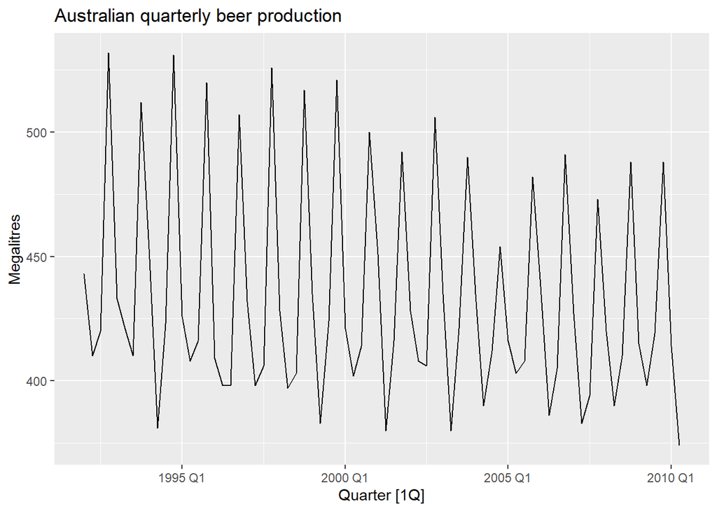

```r
recent_production <- aus_production %>%
  filter(year(Quarter) >= 1992)
recent_production %>%
  autoplot(Beer) +
  labs(y = "Megalitres",
       title = "Australian quarterly beer production")
```

We want to forecast the value of future beer production using a trend as well as a quarter factor variable. $d_i,t = 1$ if $t$ is in quarter $d_i,t = 0$ otherwise. Note that only 4-1 = 3 dummy variables are required. **The associated coefficients are measures of the difference between those quarters and the first quarter**, taken as base.

In the formulation below, `trend()` and `season()` are “special” functions that work within the `TSLM()` formula. See reference 5. for further details:

```r
fit_beer <- recent_production %>%
  model(TSLM(Beer ~ trend() + season()))
  report(fit_beer)
```

```
Series: Beer
Model: TSLM

Residuals:
     Min       1Q   Median       3Q      Max
-42.9029  -7.5995  -0.4594   7.9908  21.7895

Coefficients:
               Estimate Std. Error t value Pr(>|t|)
(Intercept)   441.80044    3.73353 118.333  < 2e-16 ***
trend()        -0.34027    0.06657  -5.111 2.73e-06 ***
season()year2 -34.65973    3.96832  -8.734 9.10e-13 ***
season()year3 -17.82164    4.02249  -4.430 3.45e-05 ***
season()year4  72.79641    4.02305  18.095  < 2e-16 ***
---
Signif. codes:  0 '***' 0.001 '**' 0.01 '*' 0.05 '.' 0.1 ' ' 1

Residual standard error: 12.23 on 69 degrees of freedom
Multiple R-squared: 0.9243, Adjusted R-squared: 0.9199
F-statistic: 210.7 on 4 and 69 DF, p-value: < 2.22e-16
```

Let us visually inspect how well the residuals fit the training data:

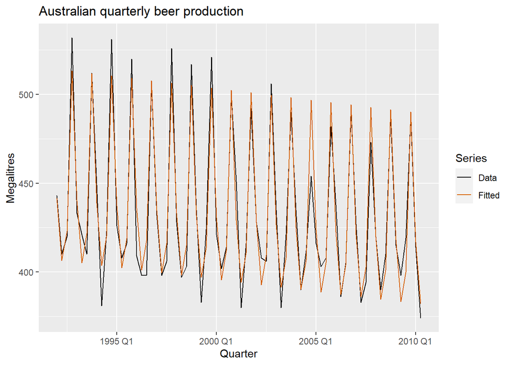

```r
augment(fit_beer) %>%
  ggplot(aes(x = Quarter)) +
  geom_line(aes(y = Beer, colour = "Data")) +
  geom_line(aes(y = .fitted, colour = "Fitted")) +
  scale_colour_manual(
    values = c(Data = "black", Fitted = "#D55E00")
  ) +
  labs(y = "Megalitres",
       title = "Australian quarterly beer production") +
  guides(colour = guide_legend(title = "Series"))
```

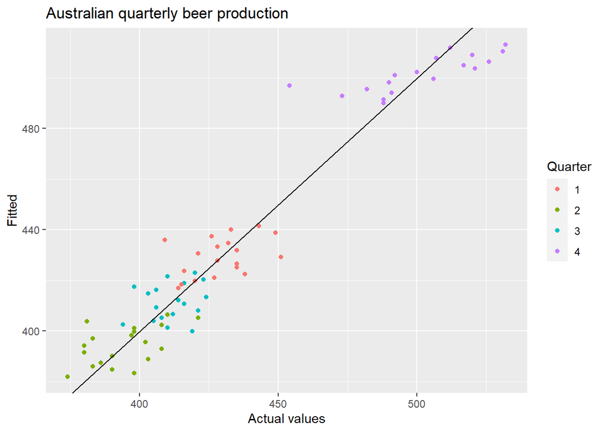

```r
augment(fit_beer) %>%
  ggplot(aes(x = Beer, y = .fitted,
             colour = factor(quarter(Quarter)))) +
  geom_point() +
  labs(y = "Fitted", x = "Actual values",
       title = "Australian quarterly beer production") +
  geom_abline(intercept = 0, slope = 1) +
  guides(colour = guide_legend(title = "Quarter"))
```

## Fourier series terms

Jean-Baptiste Fourier showed that a series of sine and cosine terms of the right frequencies can approximate any periodic function. This, of course, is utmost useful for seasonal patterns in time series.

The mathematical underpinning of Fourier analysis exceeds the scope of this course, but is important that you are familiar with the fundamental ideas and understand how they apply in the context of time series regression. Here we are interested in noting that a series of sines and cosines can be used to obtain a base of rank $m-1$ or less that captures the relevant features of our seasonal component even if its associated rank is less than $m-1$.

Let $m$ be the seasonal period we wish to model with Fourier terms. The first few Fourier terms associated to this periodic signal would be:

$$\begin{align*}
x_{1,t} = \sin\left(\textstyle\frac{2\pi t}{m}\right),
x_{2,t} = \cos\left(\textstyle\frac{2\pi t}{m}\right),
x_{3,t} = \sin\left(\textstyle\frac{4\pi t}{m}\right),\\
x_{4,t} = \cos\left(\textstyle\frac{4\pi t}{m}\right),
x_{5,t} = \sin\left(\textstyle\frac{6\pi t}{m}\right),
x_{6,t} = \cos\left(\textstyle\frac{6\pi t}{m}\right),\\
\end{align*}$$

and so on. Note that the higher the terms, the higher their frequency. The periodic signal would be the addition of all these terms. The general expression of the series would be:

$$\begin{align*}
y_t = \sum_{k=1}^{K}[\alpha_k sin(2\pi kt/m)+\beta_k cos(2\pi kt/m)] + \varepsilon(t)
\end{align*}$$

For reasons that are explained in the associated video to this part (see blackboard), the maximum value of $K$ is $m/2$. All the concepts below are further detailed in this video and it is **important that you watch it for a full understanding of this section**.

**Instead of encoding the seasonal pattern using a dummy variable associated to each subdivision of the period** as before, we could **use the first m-1** terms of the Fourier series to obtain an alternative vector base to encode the dummy variables. ($m-1$ because one of the coordinates of the seasonal component is taken as base level). For example for quarterly data ($m=4$), let us examine the first four Fourier terms:

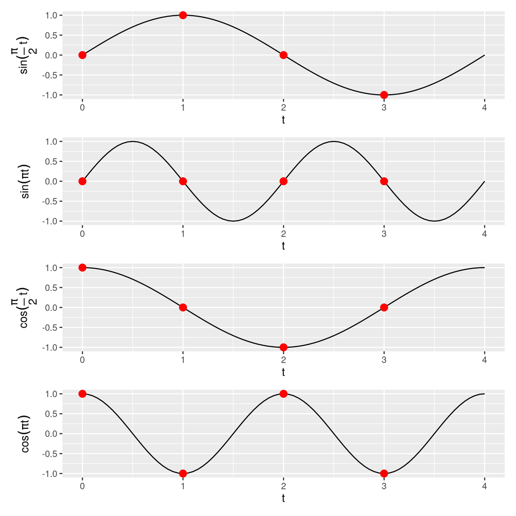

The associated vector set for each of these functions within a season would be (see red points)

{

[0, 1, 0, -1], (associated to $sin(0.5 \pi t)$)

[0, 0, 0, 0], (associated to $sin(\pi t)$)

[1, 0, -1, 0], (associated to $cos(0.5 \pi t)$)

[1, -1, 1, -1] (associated to $cos(\pi t)$)

}

When using dummy variables, the associated vector set was:

{

[1, 0, 0 , 0] (first quarter)

[0, 1, 0, 0] (second quarter)

[0, 0, 1, 0] (third quarter)

}

If we pick three linearly independent vectors from the fourier base, we may use these to model the seasonal pattern and arrive to an equivalent linear model. The coefficients associated to each vector will be different, but the vectors will combine to represent the seasonal pattern in the same manner.

### Video explanation of Fourier:

Please **watch the video dedicated to the use of Fourier terms in TS regression models to completely understand this part of the theory**. This video is **very important** and I include there additional explanations that would make this notebook too long. Then study the examples below (which are by the way covered in that video).

### First Fourier example

Let us now fit the same model for which we used dummy variables, now with Fourier terms:

```r
fourier_beer <- recent_production %>%
  model(TSLM(Beer ~ trend() + fourier(K = 2)))

report(fourier_beer)
```

```
Series: Beer
Model: TSLM

Residuals:
     Min       1Q   Median       3Q      Max
-42.9029  -7.5995  -0.4594   7.9908  21.7895

Coefficients:
                    Estimate Std. Error t value Pr(>|t|)
(Intercept)        446.87920    2.87321 155.533  < 2e-16 ***
trend()             -0.34027    0.06657  -5.111 2.73e-06 ***
fourier(K = 2)C1_4   8.91082    2.01125   4.430 3.45e-05 ***
fourier(K = 2)S1_4 -53.72807    2.01125 -26.714  < 2e-16 ***
fourier(K = 2)C2_4 -13.98958    1.42256  -9.834 9.26e-15 ***
---
Signif. codes:  0 '***' 0.001 '**' 0.01 '*' 0.05 '.' 0.1 ' ' 1

Residual standard error: 12.23 on 69 degrees of freedom
Multiple R-squared: 0.9243, Adjusted R-squared: 0.9199
F-statistic: 210.7 on 4 and 69 DF, p-value: < 2.22e-16
```

The `K` argument to `fourier()` specifies **how many pairs of sine and cosine terms to include**. Due to the multicolinearity considerations made before for categorical variables, the maximum allowed is $K = m/2$, where $m$ is the length of the seasonal period. This will result in $K$ sines and $K$ cosines. One of the sines will have 0 values at all the points of interest and therefore will not yield a vector to be used in our base for the seasonal component.

Here we have used the maximum ($4/2 = 2$) and so we arrive at an equivalent model with the exact same Adjusted R-Squared, residual standard error and degrees of freedom that when we used dummy variables for the seasonal component. Note as well that only three fourier terms ($m-1$) have been included, because the last sine is equal to 0 at all the points of interest.

If we set up `K = 1`, the seasonal pattern would be modeled using a single pair of sin and cosine functions. The associated base would look like this:

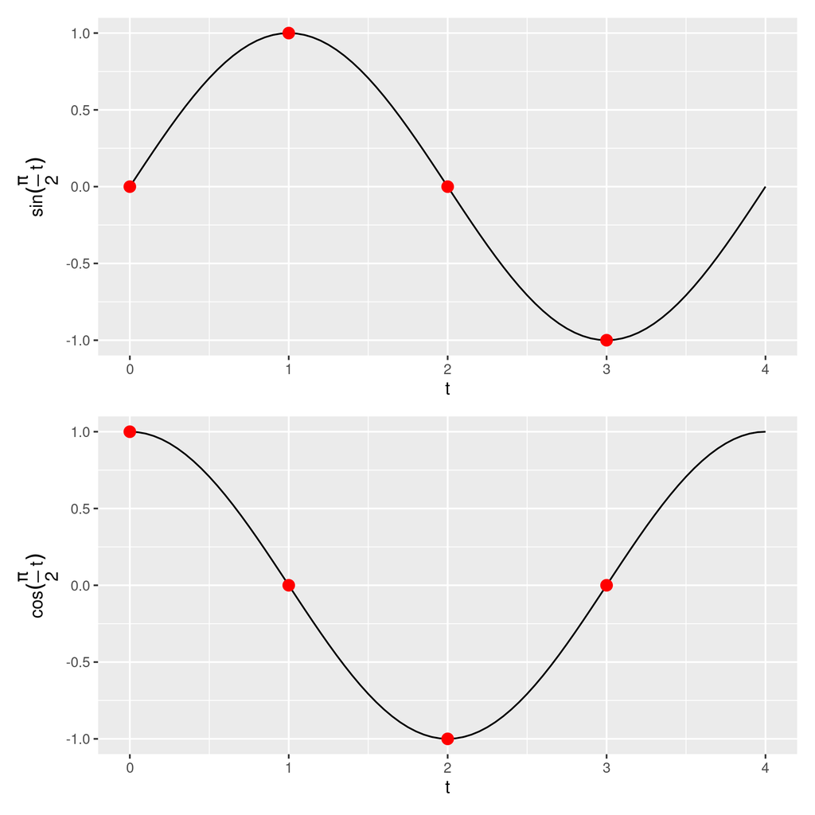

{

[0, 1, 0, -1], (associated to $sin(0.5 \pi t)$)

[1, 0, -1, 0] (associated to $cos(0.5 \pi t)$)

}

```r
fourier_beer <- recent_production %>%
  model(TSLM(Beer ~ trend() + fourier(K = 1)))
report(fourier_beer)
```

```
Series: Beer
Model: TSLM

Residuals:
    Min      1Q  Median      3Q     Max
-40.314 -13.687  -1.053  12.419  35.244

Coefficients:
                   Estimate Std. Error t value Pr(>|t|)
(Intercept)        446.3047     4.4198 100.979  < 2e-16 ***
trend()             -0.3249     0.1024  -3.173  0.00224 **
fourier(K = 1)C1_4   8.5329     3.0939   2.758  0.00741 **
fourier(K = 1)S1_4 -53.3502     3.0939 -17.243  < 2e-16 ***
---
Signif. codes:  0 '***' 0.001 '**' 0.01 '*' 0.05 '.' 0.1 ' ' 1

Residual standard error: 18.82 on 70 degrees of freedom
Multiple R-squared: 0.8182, Adjusted R-squared: 0.8104
F-statistic:   105 on 3 and 70 DF, p-value: < 2.22e-16
```

You can see that now only two fourier terms have been included and that the resulting model is different. Yet these two components capture many more features of the seasonal component than two normal dummy variables would because the Fourier terms are particularly good at picking periodic patterns associated to seasonality.

### Fourier vs dummy variables

**With Fourier terms, we often need fewer predictors than with the dummy variable approach to model a seasonal pattern with a similar level of accuracy, especially if m is large**. This makes them useful, for example, for **weekly data**, where $m = \approx 52$. Other examples could be **hourly data**, where $m = 24$.

**For short seasonal periods** (e.g. ) quarterly data, there is **little advantage in using Fourier terms over seasonal dummy variables**.

An example for weekly data is given at exercise 1 of this notebook. The solution will be provided in due curse.

### Second Fourier Example

Let us now fit an example with monthly data

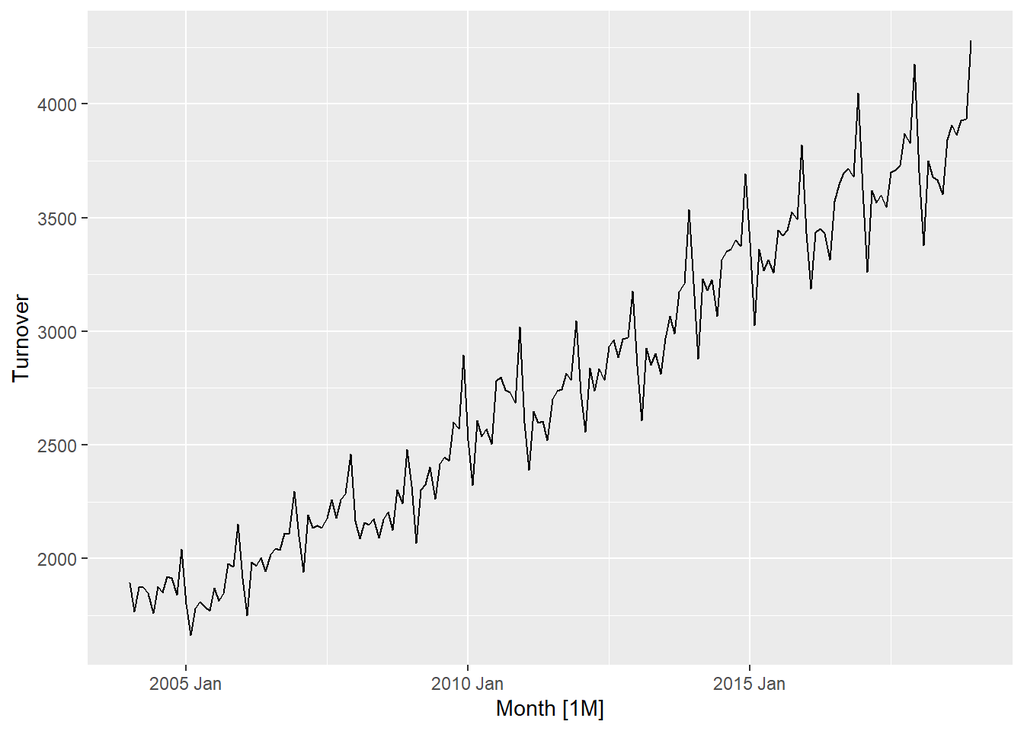

```r
aus_cafe <- aus_retail %>% filter(
    Industry == "Cafes, restaurants and takeaway food services",
    year(Month) %in% 2004:2018
    ) %>% summarise(Turnover = sum(Turnover))

aus_cafe %>% autoplot(Turnover)
```

We would now like to fit models with a growing number of pairs of sin-cosin Fourier terms to study the effect of increasing K:

```r
fit <- aus_cafe %>%
  model(
    dummies = TSLM(log(Turnover) ~ trend() + season()),
    K1 = TSLM(log(Turnover) ~ trend() + fourier(K = 1)),
    K2 = TSLM(log(Turnover) ~ trend() + fourier(K = 2)),
    K3 = TSLM(log(Turnover) ~ trend() + fourier(K = 3)),
    K4 = TSLM(log(Turnover) ~ trend() + fourier(K = 4)),
    K5 = TSLM(log(Turnover) ~ trend() + fourier(K = 5)),
    K6 = TSLM(log(Turnover) ~ trend() + fourier(K = 6))
  )

metrics <- glance(fit) %>% select(.model, r_squared, adj_r_squared, AIC, AICc)
metrics %>% arrange(AIC)
```

```
# A tibble: 7 x 5
  .model  r_squared adj_r_squared    AIC   AICc
  <chr>       <dbl>         <dbl>  <dbl>  <dbl>
1 K5          0.985         0.984 -1236. -1234.
2 dummies     0.985         0.984 -1235. -1232.
3 K6          0.985         0.984 -1235. -1232.
4 K4          0.980         0.979 -1185. -1183.
5 K3          0.976         0.975 -1161. -1160.
6 K2          0.966         0.965 -1100. -1099.
7 K1          0.962         0.962 -1086. -1085.
```

```r
AICs <- metrics %>% pull(AIC)
```

We can see that the model with the best AIC includes 5 pairs of Fourier terms. Adding an additional pair (K=6) does not substantially increase the AIC. Therefore, the optimal model we would pick is $K=5$.

Comparing the Rsquared and Adjusted RSquared and AICc of the model correspinding to K=6 and the model corresponding to the dummy variables, we may convince ourselves that these two models are indeed the same.

The dynamic image below shows the fitted values and one season forecast for an increasing K:

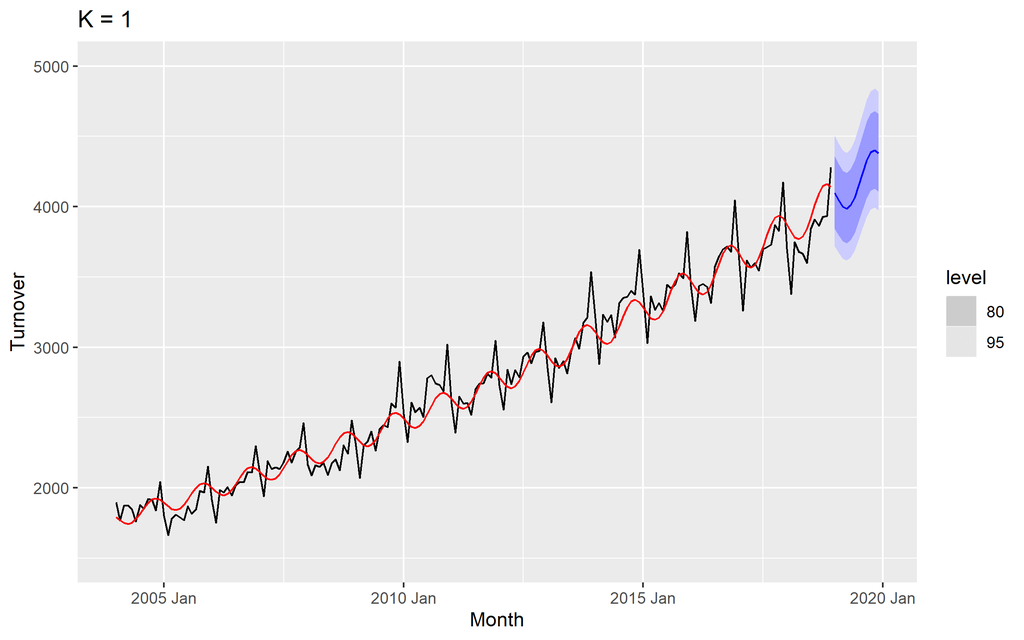

## Intervention variables

Some events may affected the variable to be forecast and not be part of the seasonal or trend components. For example:

- Competitor activity
- Unusual advertising expenditure
- Industrial action…

If the effects last only for one period, we use a “**spike”** variable. This variable takes value one in the affected span of time and zero elsewhere. It is equivalent to a dummy variable for handling an outlier.

If the effects of the intervention are permanent, we use a **“step”** dummy. Takes value zero before the intervention and one from the time of the intervention onwards.

A **change of slope in the trend** can also be considered an intervention variable. This is handled using piecewise linear regression, in the manner we saw in the section corresponding to the trend.